# 第５回データ分析勉強会

## 本日の内容

1. **再現性のあるレポーティング（午前）**
   - R Markdown概説
   - 演習（テーマ設定）
2. 再現性のあるレポーティング（午後）
   - 演習（レポート作成）
   - 発表

## 再現性のあるレポーティング

## 再現性とは？

- **データから分析結果が再現できる**こと
  - 再現可能性（Reproducibility）ともいわれる
  - 再現可能性は[CRAN Taskの一つ（Reproducible Research）](https://cran.r-project.org/web/views/ReproducibleResearch.html)
- 同じデータから同じ結果が得られることは科学的知見の蓄積において重要
  - 出典： [統計解析の再現可能性を高める取り組み](https://www.slideshare.net/YoshihikoKunisato/ss-77835559)
- 過去の分析を見直した時に何をやっているか理解できることも重要
  - その場限りの分析では知見の蓄積にならない
- 文書化（記録）されない**手作業（データ整形、コピペなど）が再現性を阻害**する
  - 人の記憶は絶対じゃない、手作業では間違いが混入しやすい

## 再現可能性ムーブメント？

[figure not shown]

Wonderful R Vol.3 & Vol.4 連続で再現可能性がテーマ

## 再現可能性を確保するには

- 分析と文書化が同時に行える仕組みを利用する
  - この仕組みが**R Markdown**
- R Markdownを使うと
  - **再現可能性**の確保
    - 常に同じ結果が得られる
  - **作業効率**の向上
    - 分析とレポーティングが同時進行
  - **リバイズ（改訂）対応**が容易
    - 追加分析や別データでの分析への対応が容易
    - 版管理システム（VCS）と組み合わせることで変更点の把握が容易

## R Markdownとは？

- Rのコードや**実行結果を文書に埋め込める**Markdown記法
- 実行結果を直接レポートにできる仕組みは**他言語には（ほぼ）ない**
  - 例外：Jupyter Notebook（旧 IPython Notebook）
    - これに触発されたのが**R Notebook**機能と思われる
- Markdownとは？
  - **プレーンテキストで**体裁のある文書を作成するための記法
  - シンプル＆ライトウェイト、テキストなので**VCSで管理可能**
  - 変換ソフト（pandocなど）の利用で**多種多様なフォーマット**に変換可能
- シンプルな記述
  - **YAML**（体裁、出力フォーマットを指定する箇所）
  - (Code) **Chunk**（実行させたいコードを記述する箇所）
  - Text (**Markdown**)（コード以外の文書を記述する箇所）

## R Markdownでできること

- **報告書・プレゼン資料の作成**
  - HTML形式だけでなくPDF形式やdocx形式もサポート（[pandoc](http://sky-y.github.io/site-pandoc-jp/users-guide/)依存）
    - 同一ソースで複数のフォーマットに対応可能
- **論文や書籍の作成**
  - （主に）海外系の学会・雑誌であれば [専用パッケージ](https://github.com/rstudio/rticles)が用意されている
  - [bookdownパッケージ](https://bookdown.org/home/)を用いることで書籍の作成が可能
- **Webページやblogの作成**
  - R Markdown Web Site機能が標準装備（今回のサイトはこれで作成）
  - [blogdownパッケージ](https://bookdown.org/yihui/blogdown/)を用いることでblogも作成可能
- その他
  - データの俯瞰に便利な[ダッシュボード](https://rmarkdown.rstudio.com/flexdashboard/examples.html)を作成可能

## 報告書の例

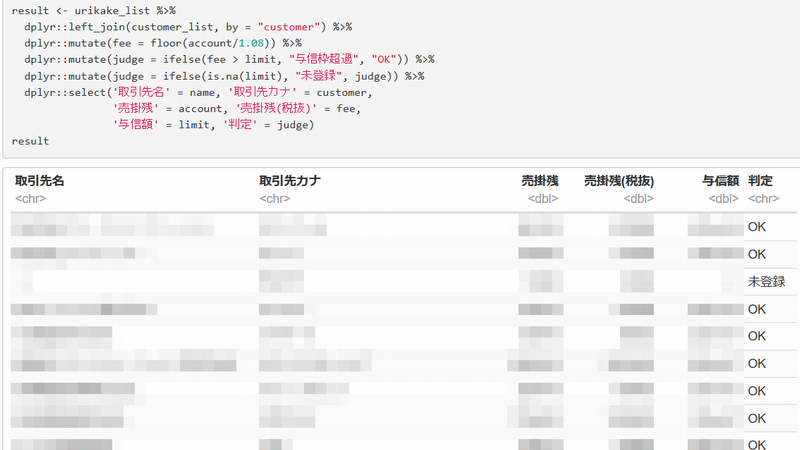

これは架空データによる利用例です

## 書籍系の例

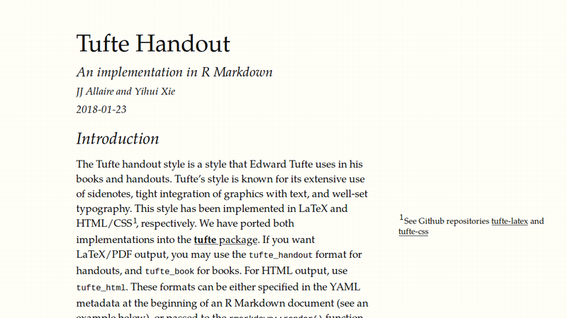

Edward Tufte Style

## Webページの例

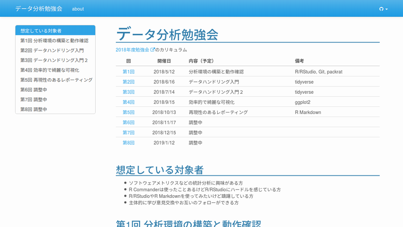

R Markdown Website + GitHub Pages

## Blogの例

[figure not shown]

blogdown + Hugo（静的サイトジェネレーター） + GitHub + Netlify（静的Webサイトホスティング）

## R以外の言語にも対応

これだけの言語がChunk内で使えます（言語環境がインストールされていることが前提）。

```r
names(knitr::knit_engines$get())
```

```
##  [1] "awk"       "bash"      "coffee"    "gawk"      "groovy"
##  [6] "haskell"   "lein"      "mysql"     "node"      "octave"
## [11] "perl"      "psql"      "Rscript"   "ruby"      "sas"
## [16] "scala"     "sed"       "sh"        "stata"     "zsh"
## [21] "highlight" "Rcpp"      "tikz"      "dot"       "c"
## [26] "fortran"   "fortran95" "asy"       "cat"       "asis"
## [31] "stan"      "block"     "block2"    "js"        "css"
## [36] "sql"       "go"        "python"    "julia"
```

RStudio v1.2からR言語以外の言語サポート、特にPythonのサポートが強化されるらしい。

## R Markdown Basics

- [R Markdown Basics](https://k-metrics.github.io/cabinet/communicate/rmd_basics.html)
  - YAML（体裁、出力フォーマットを指定する箇所）
    - YAML Ain't Markup Language
    - 構造化データなどを文字列にシリアライズ（直列化）するための形式
  - (Code) Chunk（コードを記述する箇所）
    - **R Markdown特有**の記述
    - 様々な言語による実行コードの記述・実行と実行制御が可能
  - (Text) Markdown（コード以外の文書を記述する箇所）
    - 軽量マークアップ言語（マークアップ言語：HTML, XMLなど）
    - [GitHub Flavored Markdown](https://guides.github.com/features/mastering-markdown/#GitHub-flavored-markdown)などの方言多数

## Live Preview Editor

プレビューしながら編集したい場合はMicrosoftの [Visual Studio Code](https://code.visualstudio.com/)が便利

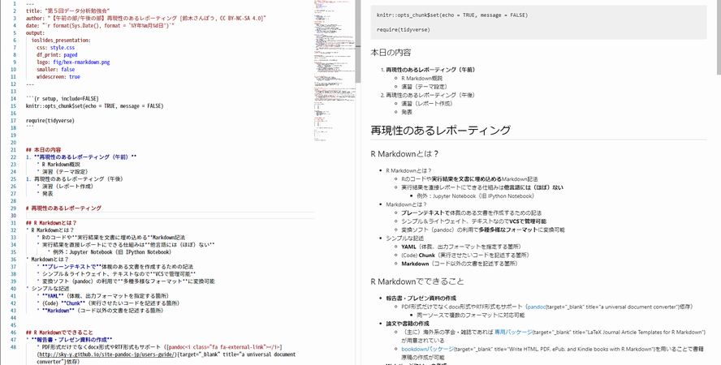

## R Markdownの仕組み

R Markdownによる再現可能性のあるドキュメント作成の仕組みは特別なものではなく汎用性のあるものです。ドキュメント生成の流れは以下のようになります。

[figure not shown]

`md`（markdown）ファイル以降の処理は[GitLab](https://about.gitlab.com/)や[Netlify](https://www.netlify.com/)などでも行われている処理と同じです。

> md -> **(build)** -> html, … -> **(deploy)** -> service

加えて`Rmd`ファイルや`md`ファイルをGit/SVNで管理することにより**変更履歴まで含めた再現可能性**の確保とドキュメント発行が効率的にできるようになります。

## 復習のためのリソース

- [R Markdown Basics](https://k-metrics.github.io/cabinet/communicate/rmd_basics.html)
- [R Markdown入門](https://kazutan.github.io/kazutanR/Rmd_intro.html)
- [R Markdown](https://rmarkdown.rstudio.com/)
- [R Markdown Cheat Sheet](https://www.rstudio.com/resources/cheatsheets/#rmarkdown)
- [R Markdown: The Definitive Guide](https://bookdown.org/yihui/rmarkdown/)
- [『再現可能性のすゝめ -RStudioによるデータ解析とレポート作成-』](http://www.kyoritsu-pub.co.jp/bookdetail/9784320112438)

R全般については

- [r-wakalang, 日本語slack community](https://qiita.com/uri/items/5583e91bb5301ed5a4ba)

## 演習

## 演習（テーマ設定）について

- チームごとに何をレポートするかのテーマを設定します
- 設定したテーマに対してR Markdownでレポートを作成します
  - テーマやデータに対して特に制限は設けません（常識的な範囲で）
  - フォーマットはHTMLであればドキュメント形式プレゼン形式を問いません
    - 勉強会サイトで公開できるように

### テーマ例

- 書籍とかには掲載されていない分布表を作ってみる（自由度の高いt分布表）
- デート本、ＳＭ本、統計学基礎の例題や問題を解いてみる
- Redmineチケットや政府統計を可視化したり仮説検定したりしてみる
- K-POPの何かの相関を分析してみる

## オープンデータの例

- [e-Stat](https://www.e-stat.go.jp/)
- [過去の気象データ・ダウンロード](https://www.data.jma.go.jp/gmd/risk/obsdl/index.php)
  - 1872年からの観測データ。気温の他に日照/日射、雲量/天気などのデータがダウンロード可能。ただし、ダウンロードできるデータ量に制限があるので必要に応じて分割してダウンロードする必要があります。
- [データカタログサイト](http://www.data.go.jp/)
- [統計データ分析コンペティション](https://www.nstac.go.jp/statcompe/)
  - e-Stat（総務省統計局）に収録されている「都道府県・市区町村のすがた（社会・人口統計体系）」の市区町村データから約100項目余を抜き出し、縦に市区町村、横にデータ項目が並ぶ表形式のデータに整備したもの。（当該ページより一部抜粋）
- [統計解析に使えるデータセットまとめ](http://hoxo-m.hatenablog.com/entry/20120214/p1)
- 今回は**スクレイピング禁止**（スクレイピングは攻撃と見なされる可能性あり）

## チーム分け（仮）

| チーム | リーダ | メンバー |
| --- | --- | --- |
| A | Ka |  |
| B | Fu |  |
| C | Ma |  |
| D | No |  |
| E | Na |  |

## 本日の内容

1. 再現性のあるレポーティング（午前）
   - R Markdown概説
   - レポーティング課題設定
2. **再現性のあるレポーティング（午後）**
   - レポート作成
   - 発表

## 再現性のあるレポーティング

## 演習（レポート作成）

| チーム | リーダ | レポートテーマ |
| --- | --- | --- |
| A | Ka |  |
| B | Fu |  |
| C | Ma |  |
| D | No |  |
| E | Na |  |

- 不明点などは適宜、相談するか質問してください

## 発表

| チーム | 発表者 | レポートテーマ |
| --- | --- | --- |
| A |  |  |
| B |  |  |
| C |  |  |
| D |  |  |
| E |  |  |

## クロージング

## シリーズ最後に

- **データハンドリング（前処理）は**可視化や分析に必要な**基本的なスキル**
  - データハンドリング（前処理）だけでも使い道は様々
  - データを扱う際には可視化して分布を確認する癖をつけておく
- 更に一連の処理の際に**再現可能性を確保**しておくことが必須条件になりつつある
- これらを非エンジニアでも実現できるのが**tidyverseを中心としたモダンなR**
  - [Six Reasons To Learn R For Business](https://www.r-bloggers.com/six-reasons-to-learn-r-for-business/)
- データ分析はソフトウェア開発者と同じようなプログラミング**周辺知識を必要**とする時代
  - BTS(Redmine, etc), VCS(Git, etc), DBMS(SQL), VM(Docker, etc), Deploy, …
- 分析技術も必要だけど**使えるデータ（\(\neq\)記録）を作らせるスキル**も必要
  - データクレンジングでなんとかならない場合も多い

## enjoy!

CC BY-NC-SA 4.0, Sampo Suzuki